# Final

data preparation, exploratory data analysis (EDA), model building, and evaluation

Data Preparation Load the libraries

```r
options(scipen = 99)
library(ggplot2)
library(ggpubr)
library(reshape2)
library(caret)
library(pROC)
library(lattice)
```

```r
df = health
```

Clean the dataset if there are any missing values

```r
df <- na.omit(df)
```

Remove unneccesary and problematic variables

```r
df$Timestamp = NULL
df$What.is.your.course. = NULL
```

Find the string of the dataset to get an overview of the data

```r
str(df)
```

```
'data.frame':   100 obs. of  9 variables:
 $ Choose.your.gender                          : Factor w/ 2 levels "Female","Male": 1 2 2 1 2 2 1 1 1 2 ...
 $ Age                                         : int  18 21 19 22 23 19 23 18 19 18 ...
 $ Your.current.year.of.Study                  : Factor w/ 7 levels "year 1","Year 1",..: 1 3 2 5 7 4 3 1 4 1 ...
 $ What.is.your.CGPA.                          : Factor w/ 6 levels "0 - 1.99","2.00 - 2.49",..: 4 4 4 4 4 5 6 5 3 5 ...
 $ Marital.status                              : Factor w/ 2 levels "No","Yes": 1 1 1 2 1 1 2 1 1 1 ...
 $ Do.you.have.Depression.                     : Factor w/ 2 levels "No","Yes": 2 1 2 2 1 1 2 1 1 1 ...
 $ Do.you.have.Anxiety.                        : Factor w/ 2 levels "No","Yes": 1 2 2 1 1 1 1 2 1 2 ...
 $ Do.you.have.Panic.attack.                   : Factor w/ 2 levels "No","Yes": 2 1 2 1 1 2 2 1 1 2 ...
 $ Did.you.seek.any.specialist.for.a.treatment.: Factor w/ 2 levels "No","Yes": 1 1 1 1 1 1 1 1 1 1 ...
 - attr(*, "na.action")= 'omit' Named int 44
  ..- attr(*, "names")= chr "44"
```

We see descriptions of each variable, whether it is an integer or a factor… We converted strings into factors when importing data therefore most of them are factors which will make our data analysis easier…

Exploratory Data Analysis

Rename columns to easier names

```r
names(df)[names(df) == "Choose.your.gender"] <- "gender"
names(df)[names(df) == "Your.current.year.of.Study"] <- "year"
names(df)[names(df) == "What.is.your.CGPA."] <- "CGPA"
names(df)[names(df) == "Marital.status"] <- "married"
names(df)[names(df) == "Do.you.have.Depression."] <- "depression"
names(df)[names(df) == "Do.you.have.Anxiety."] <- "anxiety"
names(df)[names(df) == "Do.you.have.Panic.attack."] <- "panic_attack"
names(df)[names(df) == "Did.you.seek.any.specialist.for.a.treatment."] <- "seek_help"
```

Turn ‘yes’ and ‘no’ variables to 1 and 0.

```r
df$married <- ifelse(df$married == "Yes", 1, 0)
df$depression <- ifelse(df$depression == "Yes", 1, 0)
df$anxiety <- ifelse(df$anxiety == "Yes", 1, 0)
df$panic_attack <- ifelse(df$panic_attack == "Yes", 1, 0)
df$seek_help <- ifelse(df$seek_help == "Yes", 1, 0)
```

View the summary of the dataset

```r
summary(df)
```

```
    gender        Age            year              CGPA       married       depression      anxiety      panic_attack    seek_help
 Female:75   Min.   :18.00   year 1:40   0 - 1.99    : 3   Min.   :0.00   Min.   :0.00   Min.   :0.00   Min.   :0.00   Min.   :0.00
 Male  :25   1st Qu.:18.00   Year 1: 2   2.00 - 2.49 : 2   1st Qu.:0.00   1st Qu.:0.00   1st Qu.:0.00   1st Qu.:0.00   1st Qu.:0.00
             Median :19.00   year 2:10   2.50 - 2.99 : 4   Median :0.00   Median :0.00   Median :0.00   Median :0.00   Median :0.00
             Mean   :20.53   Year 2:16   3.00 - 3.49 :43   Mean   :0.16   Mean   :0.35   Mean   :0.34   Mean   :0.33   Mean   :0.06
             3rd Qu.:23.00   year 3: 5   3.50 - 4.00 :47   3rd Qu.:0.00   3rd Qu.:1.00   3rd Qu.:1.00   3rd Qu.:1.00   3rd Qu.:0.00
             Max.   :24.00   Year 3:19   3.50 - 4.00 : 1   Max.   :1.00   Max.   :1.00   Max.   :1.00   Max.   :1.00   Max.   :1.00
                             year 4: 8
```

Visualize the summary

Create ggplots for each variable and see the distribution

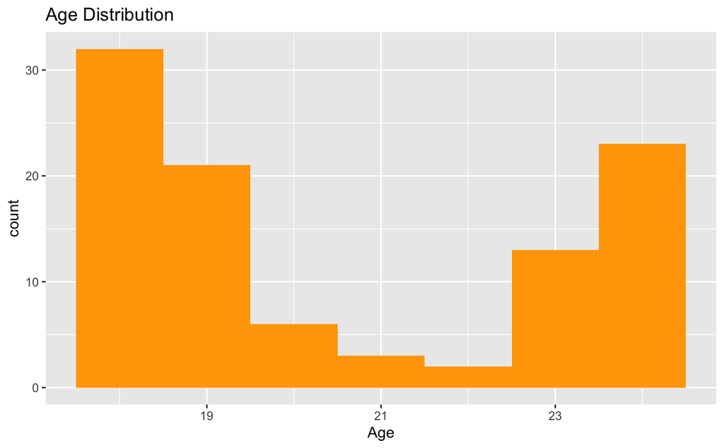

```r
ggplot(df, aes(x = Age)) +
  geom_histogram(binwidth = 1, fill = "orange") +
  labs(title = "Age Distribution")
```

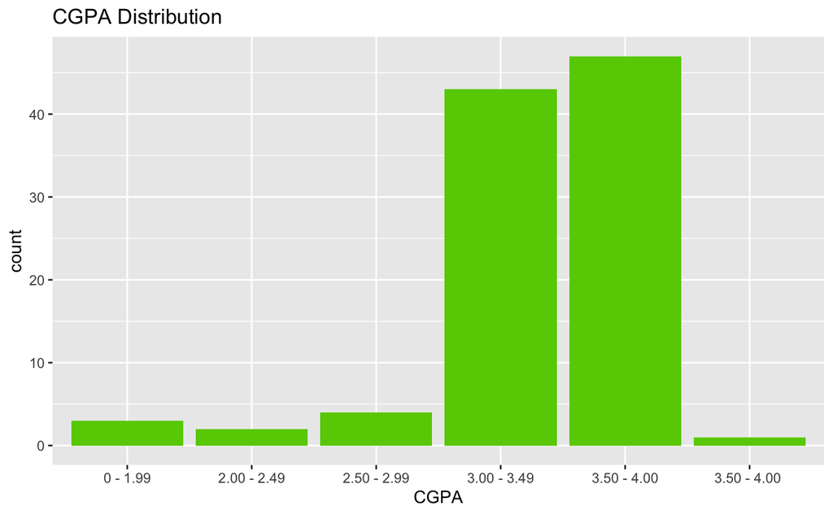

```r
ggplot(df, aes(x = CGPA)) +
  geom_bar(fill = "chartreuse3") +
  labs(title = "CGPA Distribution")
```

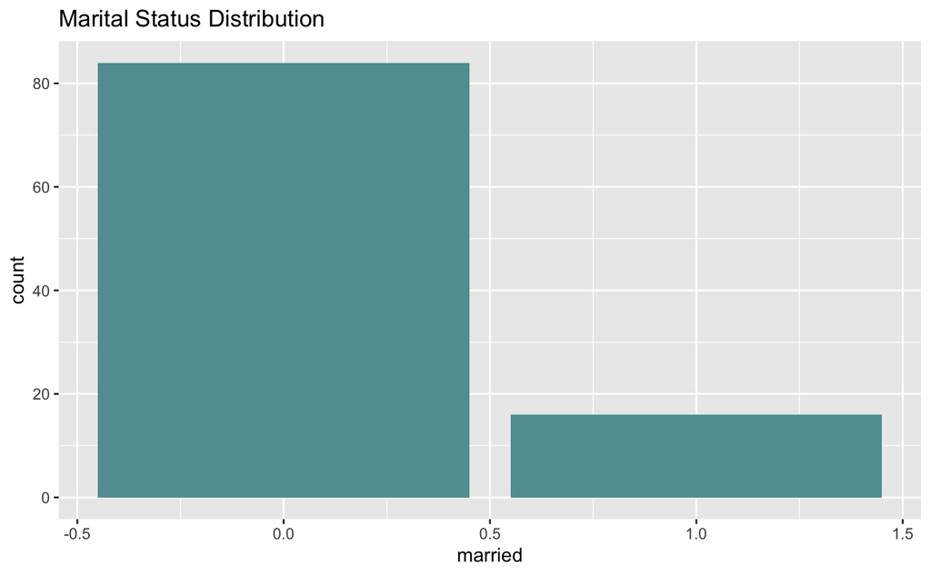

```r
ggplot(df, aes(x = married)) +
  geom_bar(fill = "cadetblue") +
  labs(title = "Marital Status Distribution")
```

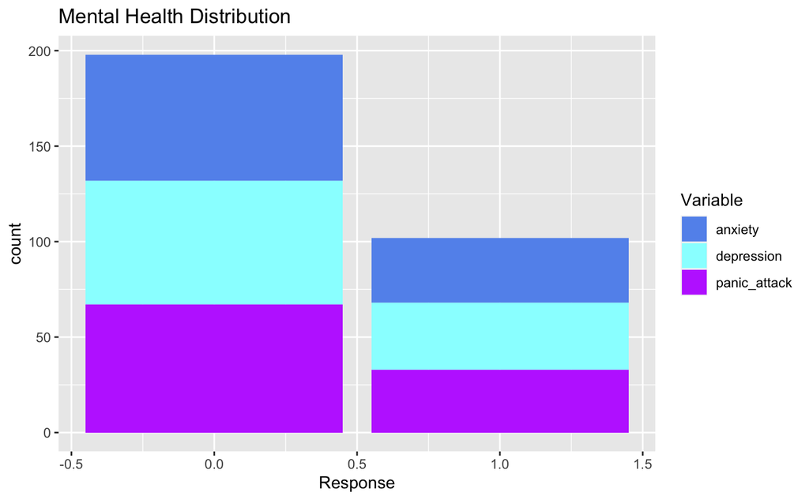

```r
library(ggplot2)

df_long <- tidyr::pivot_longer(df,
  cols = c(depression, anxiety, panic_attack),
  names_to = "Variable",
  values_to = "Response"
)

ggplot(df_long, aes(x = Response, fill = Variable)) +
  geom_bar() +
  labs(title = "Mental Health Distribution", x = "Response") +
  scale_fill_manual(values = c("depression" = "darkslategray1",
                               "anxiety" = "cornflowerblue",
                               "panic_attack" = "darkorchid1"))
```

Make visualizations

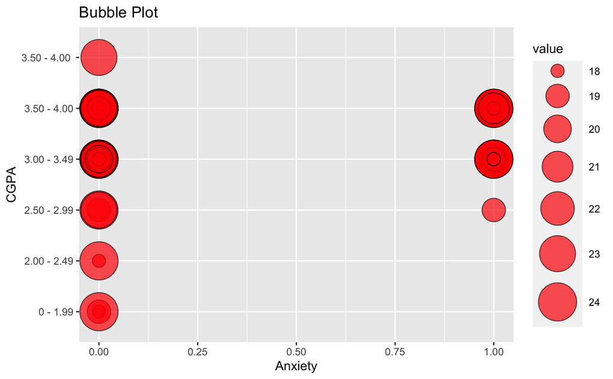

```r
data <- data.frame(
  x = df$anxiety,
  y = df$CGPA,
  value = df$Age
)

ggplot(data, aes(x = x, y = y, size = value)) +
  geom_point(shape = 21, fill = "red", color = "black", alpha = 0.7) +
  scale_size_continuous(range = c(5, 15)) +
  labs(
    title = "Bubble Plot",
    x = "Anxiety",
    y = "CGPA",
  )
```

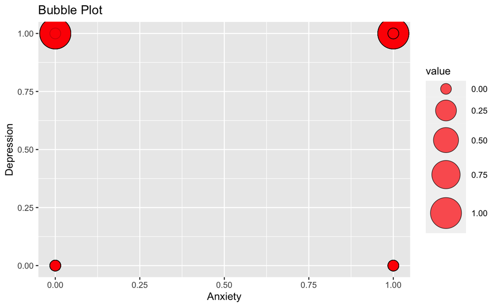

```r
data <- data.frame(
  x = df$anxiety,
  y = df$depression,
  value = df$married
)

ggplot(data, aes(x = x, y = y, size = value)) +
  geom_point(shape = 21, fill = "red", color = "black", alpha = 0.7) +
  scale_size_continuous(range = c(5, 15)) +
  labs(
    title = "Bubble Plot",
    x = "Anxiety",
    y = "Depression",
  )
```

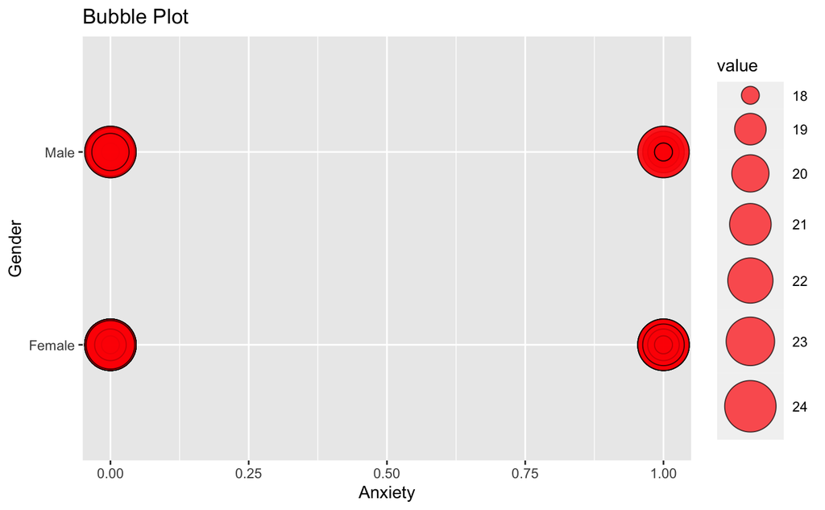

```r
data <- data.frame(
  x = df$anxiety,
  y = df$gender,
  value = df$Age
)

ggplot(data, aes(x = x, y = y, size = value)) +
  geom_point(shape = 21, fill = "red", color = "black", alpha = 0.7) +
  scale_size_continuous(range = c(5, 15)) +
  labs(
    title = "Bubble Plot",
    x = "Anxiety",
    y = "Gender",
  )
```

Find mean and Standard Deviation for numeric variables

```r
numeric_cols <- sapply(df, is.numeric)
means <- colMeans(df[, numeric_cols], na.rm = TRUE)
sds <- apply(df[, numeric_cols], 2, sd, na.rm = TRUE)

for (i in seq_along(means)) {
  cat("Column:", names(means)[i], "\n")
  cat("Mean:", means[i], "\n")
  cat("Standard Deviation:", sds[i], "\n\n")
}
```

```
Column: Age
Mean: 20.53
Standard Deviation: 2.49628

Column: married
Mean: 0.16
Standard Deviation: 0.3684529

Column: depression
Mean: 0.35
Standard Deviation: 0.4793725

Column: anxiety
Mean: 0.34
Standard Deviation: 0.4760952

Column: panic_attack
Mean: 0.33
Standard Deviation: 0.4725816

Column: seek_help
Mean: 0.06
Standard Deviation: 0.2386833
```

Visualize the Mean and SD

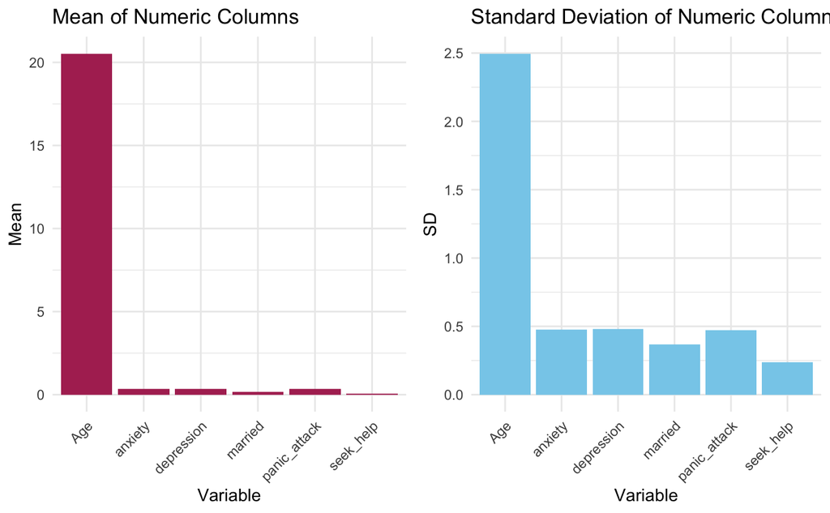

```r
summary_data <- data.frame(
  Variable = names(means),
  Mean = means,
  SD = sds
)

mean_plot <- ggplot(summary_data, aes(x = Variable, y = Mean)) +
  geom_bar(stat = "identity", fill = "maroon") +
  labs(title = "Mean of Numeric Columns") +
  theme_minimal() +
  theme(axis.text.x = element_text(angle = 45, hjust = 1))

sd_plot <- ggplot(summary_data, aes(x = Variable, y = SD)) +
  geom_bar(stat = "identity", fill = "skyblue") +
  labs(title = "Standard Deviation of Numeric Columns") +
  theme_minimal() +
  theme(axis.text.x = element_text(angle = 45, hjust = 1))

library(gridExtra)
grid.arrange(mean_plot, sd_plot, ncol = 2)
```

Model Building

Split Data

```r
test_size <- 0.2

set.seed(123)

data_split <- createDataPartition(df$anxiety, p = test_size, list = FALSE)

training_data <- df[data_split, ]
testing_data <- df[-data_split, ]
```

Logistic Classification

```r
model <- glm(anxiety ~., data = df, family = binomial)

summary(model)
```

```
Call:
glm(formula = anxiety ~ ., family = binomial, data = df)

Coefficients:
                   Estimate Std. Error z value Pr(>|z|)
(Intercept)       -17.53435 2275.17143  -0.008  0.99385
genderMale          0.59261    0.57584   1.029  0.30343
Age                -0.02257    0.10255  -0.220  0.82582
yearYear 1          0.04389    1.64700   0.027  0.97874
yearyear 2         -0.17777    0.86764  -0.205  0.83766
yearYear 2          0.85272    0.74265   1.148  0.25088
yearyear 3         -0.31035    1.31757  -0.236  0.81378
yearYear 3          0.22313    0.69299   0.322  0.74746
yearyear 4          0.07168    0.96144   0.075  0.94057
CGPA2.00 - 2.49    -0.51526 3454.64383   0.000  0.99988
CGPA2.50 - 2.99    15.40950 2275.17096   0.007  0.99460
CGPA3.00 - 3.49    16.22714 2275.17058   0.007  0.99431
CGPA3.50 - 4.00    16.82241 2275.17055   0.007  0.99410
CGPA3.50 - 4.00    -0.62596 4563.74463   0.000  0.99989
married            -0.65829    0.85831  -0.767  0.44311
depression          1.72495    0.66627   2.589  0.00963 **
panic_attack        0.22441    0.54733   0.410  0.68180
seek_help          -0.22538    1.10121  -0.205  0.83784
---
Signif. codes:  0 ‘***’ 0.001 ‘**’ 0.01 ‘*’ 0.05 ‘.’ 0.1 ‘ ’ 1

(Dispersion parameter for binomial family taken to be 1)

    Null deviance: 128.21  on 99  degrees of freedom
Residual deviance: 110.51  on 82  degrees of freedom
AIC: 146.51

Number of Fisher Scoring iterations: 16
```

The coefficients provide information on the strength of the relationship between the predictor variables and the probability of having anxiety. The higher the estimate the stronger the relationship is towards the target variable.

```r
new_data <- df[, -which(names(df) == "anxiety")]
```

```r
predictions <- predict(model, newdata = new_data, type = "response")
predictions
```

[output not shown]

Formula

```r
coefficients <- coef(model)

intercept <- coefficients[1]
other_coefficients <- coefficients[-1]

equation <- paste("P(Y=1|X) = 1 / (1 + exp(-(", paste(intercept, paste(other_coefficients, collapse = " * "), sep = " + "), "))")

print(equation)
```

[output not shown]

Visualize predictions

```r
threshold <- 0.5

predicted_class <- ifelse(predictions >= threshold, 1, 0)

plot(1:length(predictions), predictions, type = "l", col = "blue", lwd = 2,
     main = "Predicted Probabilities with Threshold", xlab = "Sample", ylab = "Probability")

abline(h = threshold, col = "red", lty = 2)
```

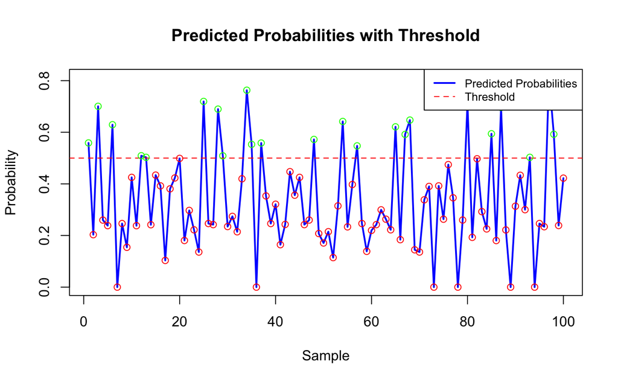

```r
points(1:length(predictions), predictions, col = ifelse(predicted_class == 1, "green", "red"))

legend("topright", legend = c("Predicted Probabilities", "Threshold"),
       col = c("blue", "red"), lty = c(1, 2), lwd = c(2, 1), cex = 0.8)
```

The red dots mean 0 and green mean 1. The red line is the threshold, if there are more red dots, there were more predictions of 0. They should fall more under the threshold.

```r
predicted_labels <- ifelse(predictions > 0.5, 1, 0)
actual_labels <- df$anxiety

confusion_matrix <- table(Actual = df$anxiety, Predicted = predicted_labels)

accuracy <- sum(diag(confusion_matrix)) / sum(confusion_matrix)
sensitivity <- confusion_matrix[2, 2] / sum(confusion_matrix[2, ])
specificity <- confusion_matrix[1, 1] / sum(confusion_matrix[1, ])

print(confusion_matrix)
```

```
      Predicted
Actual  0  1
     0 56 10
     1 21 13
```

```r
cat("Accuracy:", accuracy, "\n")
```

```
Accuracy: 0.69
```

```r
cat("Sensitivity:", sensitivity, "\n")
```

```
Sensitivity: 0.3823529
```

```r
cat("Specificity:", specificity, "\n")
```

```
Specificity: 0.8484848
```

Accuracy - 69%

Visual for the confusion matrix

[figure not shown]

Accuracy: 69%

Visualizations ROC Curve

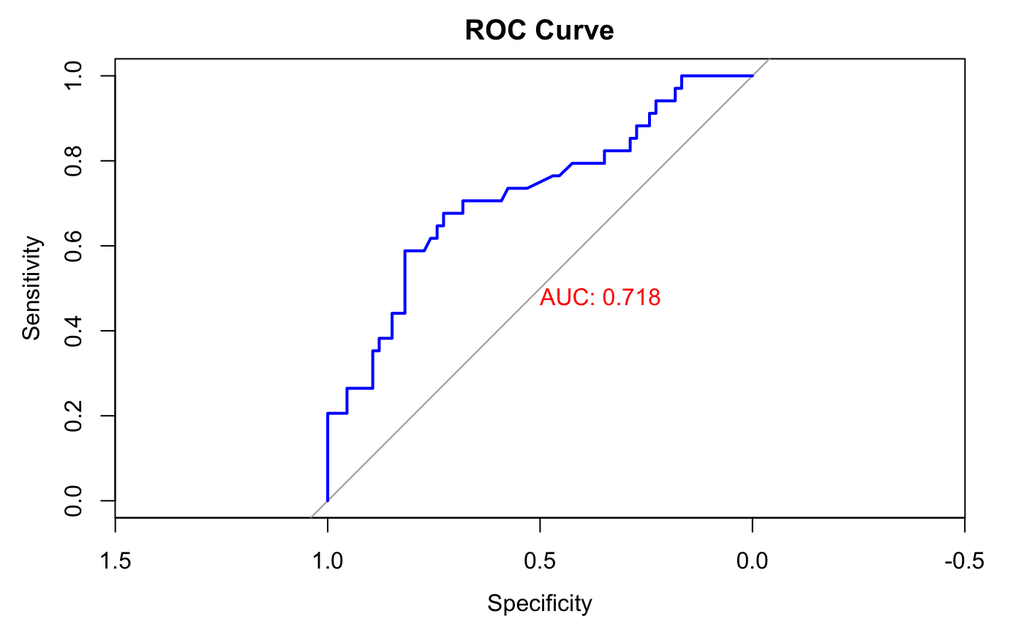

```r
library(pROC)

roc_obj <- roc(df$anxiety, predictions)
plot(roc_obj, main = "ROC Curve", print.auc = TRUE, col = "blue", print.auc.col = "red")
```

```r
auc_value <- auc(roc_obj)
cat("AUC:", auc_value, "\n")
```

```
AUC: 0.7183601
```

Blue line positioned closer to upper left corner - better accuracy of prediction. This curve is moderate.

Multinomial Naive Bayes

Load the neccessary library

```r
library(naivebayes)
```

Turn training data into factor and create naive bayes model

```r
training_data$anxiety <- as.factor(training_data$anxiety)
model_MNB <- naive_bayes(anxiety ~ ., data = training_data, laplace = 1)
```

Run predictions

```r
y_pred <- predict(model_MNB, newdata = testing_data)
y_pred
```

```
 [1] 1 1 1 1 1 1 1 1 1 1 1 1 1 1 1 1 1 1 1 1 1 1 1 0 1 1 1 0 1 1 1 1 0 1 1 1 1 1 1 1 1 1 1 1 1 1 1 1 1 1 1 1 1 1 1 1 1 1 1 1 1 1 1 1 1 1 1
[68] 1 1 1 1 1 1 0 1 1 1 1 1 1
Levels: 0 1
```

Visualizations Predictions

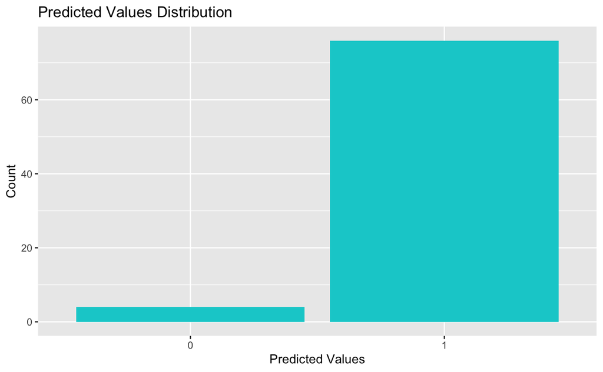

```r
library(ggplot2)
predictions_df <- data.frame(Predicted = y_pred)

prediction_barplot <- ggplot(data = predictions_df, aes(x = Predicted)) +
  geom_bar(fill = "darkturquoise") +
  xlab("Predicted Values") +
  ylab("Count") +
  ggtitle("Predicted Values Distribution")

print(prediction_barplot)
```

Way more predicted values are 1 (yes) than 0(no).

Make testing data into factor

```r
testing_data$anxiety <- as.factor(testing_data$anxiety)
```

Create confusion matrix

```r
confusion_matrix <- confusionMatrix(y_pred, testing_data$anxiety)
confusion_matrix
```

```
Confusion Matrix and Statistics

          Reference
Prediction  0  1
         0  2  2
         1 50 26

               Accuracy : 0.35
                 95% CI : (0.2467, 0.4648)
    No Information Rate : 0.65
    P-Value [Acc > NIR] : 1

                  Kappa : -0.0236

 Mcnemar's Test P-Value : 0.00000000007138

            Sensitivity : 0.03846
            Specificity : 0.92857
         Pos Pred Value : 0.50000
         Neg Pred Value : 0.34211
             Prevalence : 0.65000
         Detection Rate : 0.02500
   Detection Prevalence : 0.05000
      Balanced Accuracy : 0.48352

       'Positive' Class : 0
```

Accuracy: 35%

Confusion Matrix visuals

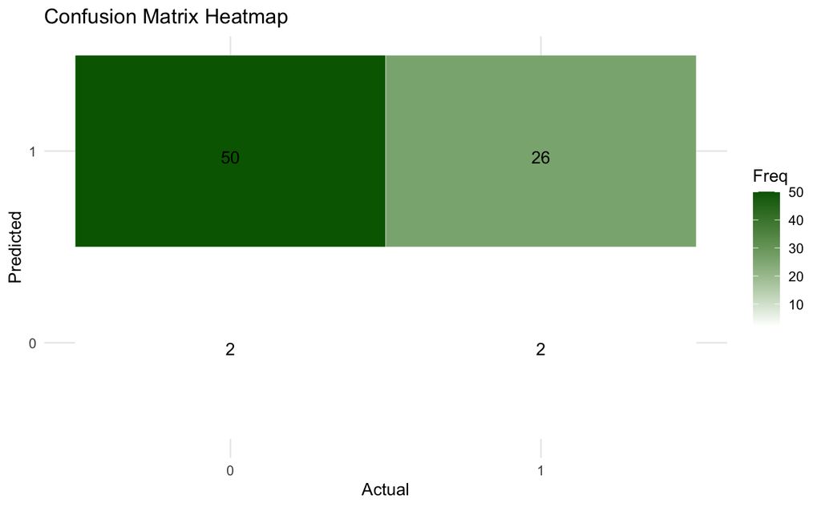

```r
confusion_df <- as.data.frame(as.table(confusion_matrix$table))

ggplot(confusion_df, aes(x = Reference, y = Prediction, fill = Freq)) +
  geom_tile(color = "white") +
  scale_fill_gradient(low = "white", high = "darkgreen") +
  geom_text(aes(label = Freq), vjust = 1) +
  theme_minimal() +
  labs(title = "Confusion Matrix Heatmap", x = "Actual", y = "Predicted")
```

Bernoulli Naive Bayes

```r
library(e1071)
```

```r
test_size <- 0.2

set.seed(123)

data_split <- createDataPartition(df$anxiety, p = test_size, list = FALSE)

training_data_BNB <- df[data_split, ]
testing_data_BNB <- df[-data_split, ]
```

```r
training_data_BNB$anxiety <- as.factor(training_data_BNB$anxiety)

model_BNB <- naiveBayes(anxiety ~ ., data = training_data, laplace = 1)
```

Make predictions

```r
y_pred_BNB <- predict(model_BNB, newdata = testing_data_BNB)
y_pred_BNB
```

```
 [1] 1 1 1 1 1 1 1 1 1 1 1 1 1 1 1 1 1 1 1 1 1 1 1 0 1 1 1 0 1 1 1 1 0 1 1 1 1 1 1 1 1 1 1 1 1 1 1 1 1 1 1 1 1 1 1 1 1 1 1 1 1 1 1 1 1 1 1
[68] 1 1 1 1 1 1 0 1 1 1 1 1 1
Levels: 0 1
```

Visuals

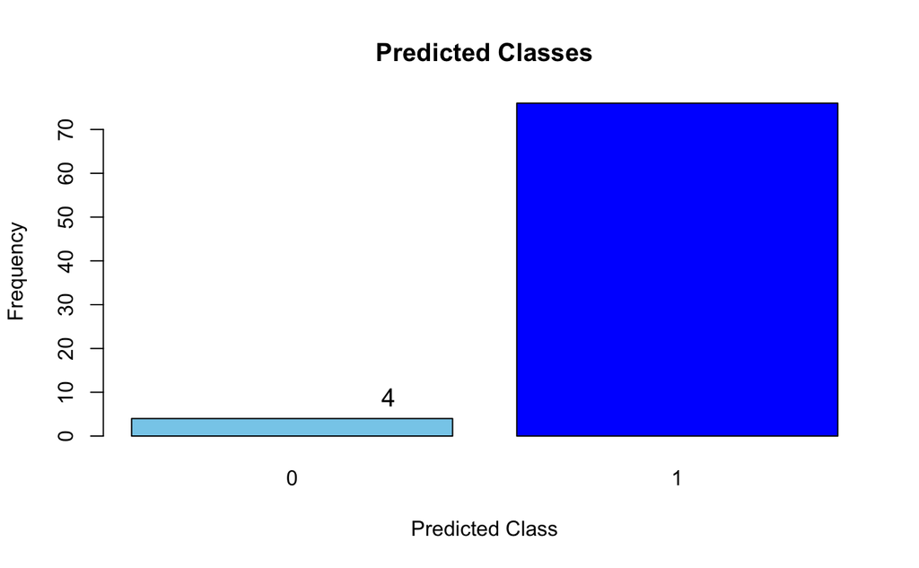

```r
barplot(table(y_pred), col = c("skyblue", "blue"),
        xlab = "Predicted Class",
        ylab = "Frequency",
        main = "Predicted Classes")

text(1:2, table(y_pred), labels = table(y_pred), pos = 3, cex = 1.2)
```

```r
testing_data_BNB$anxiety <- as.factor(testing_data_BNB$anxiety)
```

```r
confusion_matrix <- confusionMatrix(y_pred_BNB, testing_data_BNB$anxiety)
confusion_matrix
```

```
Confusion Matrix and Statistics

          Reference
Prediction  0  1
         0  2  2
         1 50 26

               Accuracy : 0.35
                 95% CI : (0.2467, 0.4648)
    No Information Rate : 0.65
    P-Value [Acc > NIR] : 1

                  Kappa : -0.0236

 Mcnemar's Test P-Value : 0.00000000007138

            Sensitivity : 0.03846
            Specificity : 0.92857
         Pos Pred Value : 0.50000
         Neg Pred Value : 0.34211
             Prevalence : 0.65000
         Detection Rate : 0.02500
   Detection Prevalence : 0.05000
      Balanced Accuracy : 0.48352

       'Positive' Class : 0
```

Accuracy: 35%

Visuals Confusion matrix heatmap

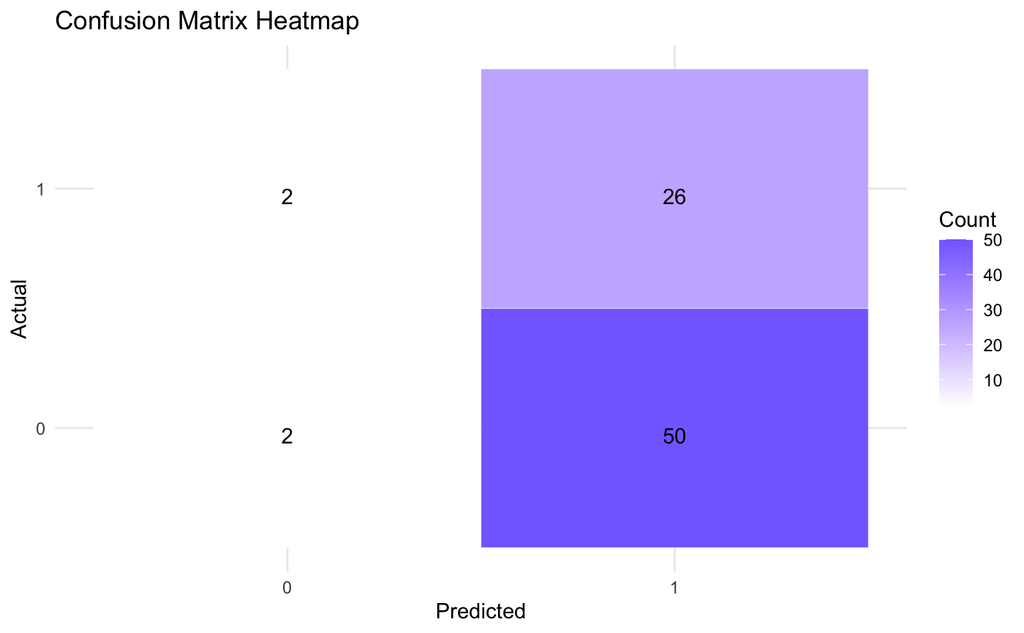

```r
confusion_df <- as.data.frame(as.table(conf_matrix$table))
colnames(confusion_df) <- c("Predicted", "Actual", "Count")

ggplot(confusion_df, aes(x = Predicted, y = Actual, fill = Count)) +
  geom_tile(color = "white") +
  scale_fill_gradient(low = "white", high = "lightslateblue") +
  geom_text(aes(label = Count), vjust = 1) +
  theme_minimal() +
  labs(title = "Confusion Matrix Heatmap", x = "Predicted", y = "Actual")
```

GBM model

#Split data again if neccessary

```r
library(gbm)
formula <- anxiety ~ .

gbm_model <- gbm(formula, data = training_data, distribution = "bernoulli", n.trees = 100, interaction.depth = 4, bag.fraction = 0.7, n.minobsinnode = 5)

predictions <- predict(gbm_model, newdata = testing_data, type = "response", n.trees = 100)

binary_predictions <- ifelse(predictions > 0.5, 1, 0)

confusion_matrix <- table(binary_predictions, testing_data$anxiety)
print(confusion_matrix)
```

```
binary_predictions  0  1
                 0 44 20
                 1  8  8
```

```r
accuracy <- sum(diag(confusion_matrix)) / sum(confusion_matrix)
print(paste("Accuracy:", accuracy))
```

```
[1] "Accuracy: 0.65"
```

65% accuracy

```r
TP <- confusion_matrix[2, 2]
TN <- confusion_matrix[1, 1]
FP <- confusion_matrix[1, 2]
FN <- confusion_matrix[2, 1]

sensitivity <- TP / (TP + FN)
specificity <- TN / (TN + FP)
cat("Sensitivity:", sensitivity, "\n")
```

```
Sensitivity: 0.5
```

```r
cat("Specificity:", specificity, "\n")
```

```
Specificity: 0.6875
```

Visuals

```r
plot(predictions, type = "l", col = "blue", lwd = 2, xlab = "Observation", ylab = "Probability", main = "GBM Predictions")
abline(h = 0.5, col = "red", lty = 2)  # Threshold line
```

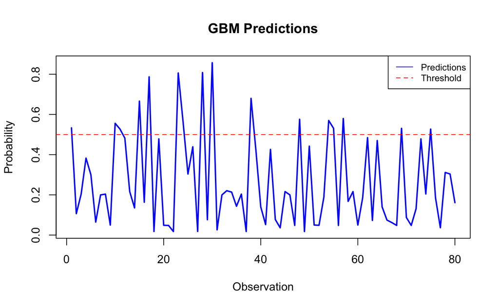

```r
legend("topright", legend = c("Predictions", "Threshold"), col = c("blue", "red"), lty = 1:2, cex = 0.8)
```

The red line is the threshold. Lines that are over the threshold are 1, and below - 0. There are more 0’s than 1’s, thus the predictions is no anxiety.

Confusion Matrix Heatmap

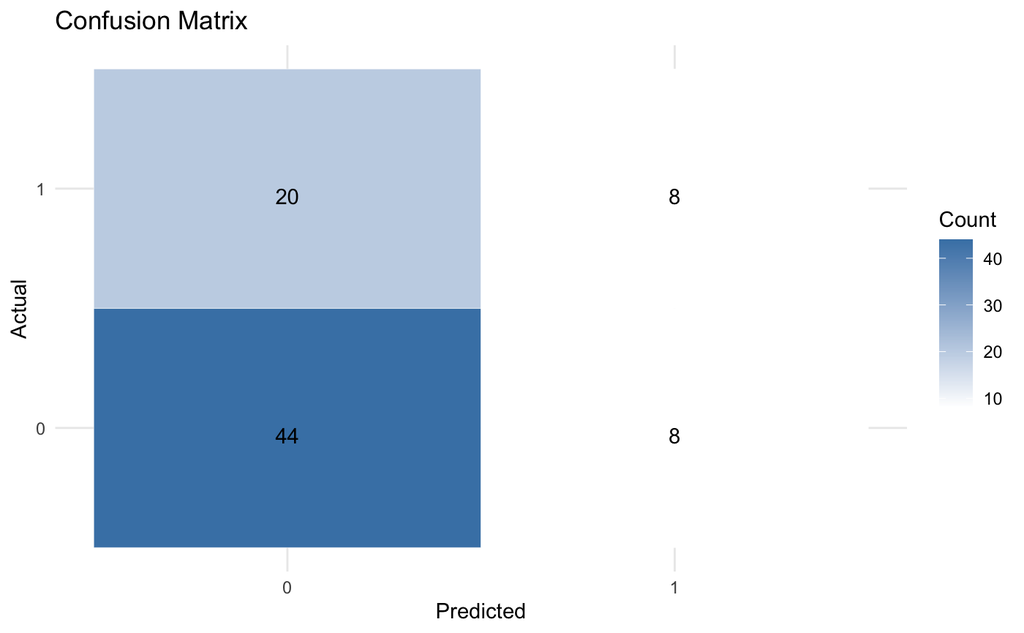

```r
library(ggplot2)
library(reshape2)

confusion_df <- as.data.frame(as.table(confusion_matrix))
colnames(confusion_df) <- c("Predicted", "Actual", "Count")

ggplot(confusion_df, aes(x = Predicted, y = Actual, fill = Count)) +
  geom_tile(color = "white") +
  scale_fill_gradient(low = "white", high = "steelblue") +
  geom_text(aes(label = Count), vjust = 1) +
  theme_minimal() +
  labs(title = "Confusion Matrix", x = "Predicted", y = "Actual")
```

Most are true negatives